# DigiCAP UCC Capstone Project Presentation by Samuel Kwame Dassi

[figure not shown]

# OUTLINE

## 1. A brief Overview of the Project

## 2. Performing basic statistical descriptives

## 3. Visualizations of the stock features

## 4. Distributions - Calculating Historical Returns and Statistical Measures

## 5. Simulations - Simulating the Future Daily Returns for investor in goil stocks and Future Prices.

## 6. Quantifications - Examining the worst, average, best scenarios and the probability distribution of each

## 7. Conclusion

# A Brief Overview of the Project

# The Goal of this Project is to use Monte Carlo Simulation to Predict the Closing Stock Price of Ghana Oil Company Ltd (GOIL).

[figure not shown]

## Historical Data From November 16 2007 to August 23 2022 was downloded for the analysis.

## Goil was enlisted on the Ghana Stock Exchange on 16th November, 2007.

## Source of Data is from Ghana Stock Exchange Database. The data was downloaded on August 23 2022

## The Ghana Stock Exchage opens for trading five days a week. Mondays to Fridays excluding holidays. Five hours a day, 10am to 3pm

## Approximately the Exchange trades for 250 days a year.

## The snapshot of the whole data set is as follows

|  | Date | Share Code | Year High (GHS) | Year Low (GHS) | Previous Closing Price VWAP (GHS) | Opening Price (GHS) | Closing Price VWAP (GHS) | Price Change (GHS) | Closing Bid Price (GHS) | Closing Offer Price (GHS) | Total Shares Traded | Total Value Traded | Last Transaction Price (GHS) |
| --- | --- | --- | --- | --- | --- | --- | --- | --- | --- | --- | --- | --- | --- |
| 0 | 2007-11-16 | GOIL | 0.2153 | 0.215 | 0.2000 | 0.2150 | 0.2153 | 0.0153 | NaN | NaN | 62800 | NaN | 0 |
| 1 | 2007-11-19 | GOIL | 0.2153 | 0.215 | 0.2153 | 0.2153 | 0.2153 | 0.0000 | 0.2154 | 0.0 | 0 | NaN | 0 |
| 2 | 2007-11-20 | GOIL | 0.2153 | 0.215 | 0.2153 | 0.2153 | 0.2153 | 0.0000 | 0.2155 | 0.0 | 0 | NaN | 0 |
| 3 | 2007-11-21 | GOIL | 0.2260 | 0.215 | 0.2153 | 0.2153 | 0.2260 | 0.0107 | 0.2260 | 0.0 | 1090400 | NaN | 0 |
| 4 | 2007-11-22 | GOIL | 0.2260 | 0.215 | 0.2260 | 0.2260 | 0.2260 | 0.0000 | 0.2260 | 0.0 | 0 | NaN | 0 |

|  | Date | Share Code | Year High (GHS) | Year Low (GHS) | Previous Closing Price VWAP (GHS) | Opening Price (GHS) | Closing Price VWAP (GHS) | Price Change (GHS) | Closing Bid Price (GHS) | Closing Offer Price (GHS) | Total Shares Traded | Total Value Traded | Last Transaction Price (GHS) |
| --- | --- | --- | --- | --- | --- | --- | --- | --- | --- | --- | --- | --- | --- |
| 3624 | 2022-08-17 | GOIL | 1.82 | 1.79 | 1.79 | 1.79 | 1.79 | 0.0 | NaN | 1.79 | 0 | 0 | 1.79 |
| 3625 | 2022-08-18 | GOIL | 1.82 | 1.79 | 1.79 | 1.79 | 1.79 | 0.0 | NaN | 1.79 | 0 | 0 | 1.79 |
| 3626 | 2022-08-19 | GOIL | 1.82 | 1.79 | 1.79 | 1.79 | 1.79 | 0.0 | NaN | 1.79 | 20 | 35.8 | 1.79 |
| 3627 | 2022-08-22 | GOIL | 1.82 | 1.79 | 1.79 | 1.79 | 1.79 | 0.0 | NaN | 1.79 | 0 | 0 | 1.79 |
| 3628 | 2022-08-23 | GOIL | 1.82 | 1.79 | 1.79 | 1.79 | 1.79 | 0.0 | NaN | 1.79 | 0 | 0 | 1.79 |

# Performing basic statistical descriptives on the data show that:

## 1. the mean closing stock for goil is GHS 1.25 with standard deviation of GHS 0.96

## 2. The minimum price is 0.14 and a maximum price of 5.01.

## 3. This leads to a range of GHs 4.87

## 4. The price dropped by as low as 0.37 at some point and rose by 1.59 at some other time

|  | Year High (GHS) | Year Low (GHS) | Previous Closing Price VWAP (GHS) | Opening Price (GHS) | Closing Price VWAP (GHS) | Price Change (GHS) | Closing Bid Price (GHS) | Closing Offer Price (GHS) |
| --- | --- | --- | --- | --- | --- | --- | --- | --- |
| count | 3629.000000 | 3629.000000 | 3629.000000 | 3629.000000 | 3629.000000 | 3629.000000 | 2310.000000 | 2584.000000 |
| mean | 1.448337 | 1.060518 | 1.247194 | 1.246633 | 1.247439 | 0.001631 | 1.025457 | 3.885404 |
| std | 1.205101 | 0.834795 | 0.964101 | 0.963641 | 0.964143 | 0.045487 | 0.906220 | 135.718681 |
| min | 0.170000 | 0.020000 | 0.140000 | 0.140000 | 0.140000 | -0.370000 | 0.000000 | 0.000000 |
| 25% | 0.340000 | 0.300000 | 0.330000 | 0.330000 | 0.330000 | 0.000000 | 0.300000 | 0.320000 |
| 50% | 1.440000 | 1.050000 | 1.120000 | 1.120000 | 1.120000 | 0.000000 | 0.900000 | 1.000000 |
| 75% | 1.780000 | 1.500000 | 1.700000 | 1.700000 | 1.700000 | 0.000000 | 1.500000 | 1.700000 |
| max | 5.050000 | 4.350000 | 5.010000 | 5.010000 | 5.010000 | 1.590000 | 5.000000 | 6900.000000 |

### The shares of goil was traded on the exchange for 3,629 days with 13 features

## The focus of this project will be on GOIL's closing stock price only. This closing price will be used to simulate the possible prices for the next 250 days of trade on the Ghana Stock Exchange.

## Even though four columns of the dataset have some null values, their presence will not affect the simulation and prediction.These columns are:

## a. Closing Bid Price (GHS)

## b. Closing Offer Price (GHS),

## c. Total Shares Traded and

## d. Total Value Traded

## There are 6 duplicate values in the data that ware removed. This should reduce the dimension of the data set to 3623 by 13

# Visualizations of the stock features

## Since the data set is a time series data, line graphs are used to study the trend of the features

### . It can be realised that there has been some improvemnet in the performance from the begining of 2022.

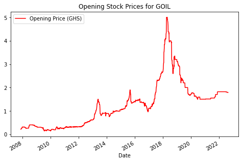

## The performance of the clossing price also follows that of the openning price. The same attributes equally explain the performance of the closing price.

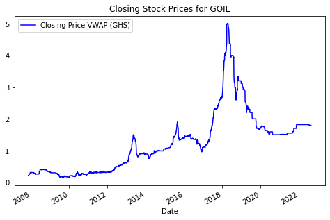

## Thi is evident in the rise and fall of the price changes.

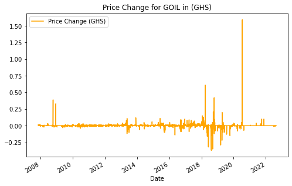

## The Year High and Year low all follow the same trend as the prices.

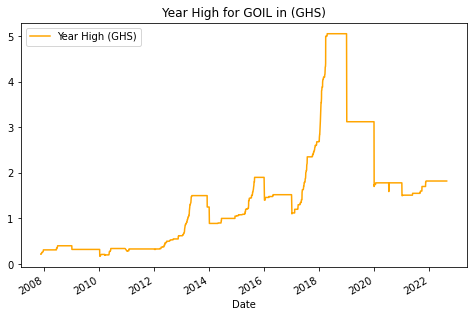

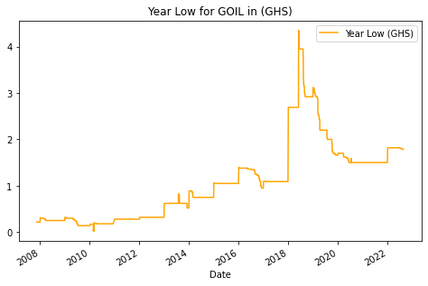

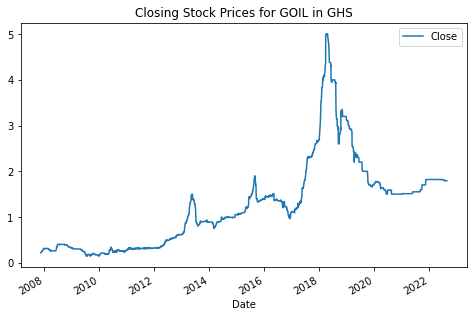

# Distributions - Calculating Historical Returns and Statistical Measures

## Since this project seeks to predict closing stock prices, The 'Close' column will be the focus

## The log return of goil stock indicates that at some points invetors gain and lose at some other times.

## From the graph, it can be seen that goil stock returns for investors has been a little volatile. As shown in the performance of the percentage changes.

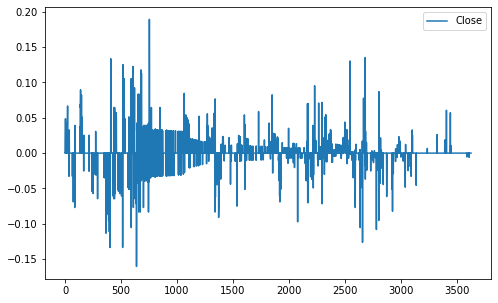

# Simulations - Simulating the Future Daily Returns for an investor in goil stocks and Future Prices.

## 100 randomly choosen numbers are used to simulate the future daily returns for the next 250 trading days.

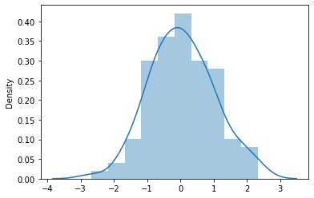

## The Stock Exhange opens from Monday to Fridays excluding holidays.

## Trading on the floor starts at 10am to 3pm each working day.

## Due to this we assumed that trading occurs 250 times hence a time interval of 250 is used for the calculation with the 100 randomly choosen simulation numbers.

## The graph below shows the worst case scenairo and best case scenario for all 100 instances of simulations

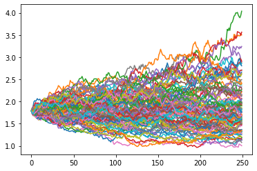

# Quantifications - Examining the worst, average, best scenarios and the probability distribution of each

## . In the worst case, Goil prices traded around GH1.00

## . On average case, Goil prices traded around GH1.89

## . In the best case, Goil prices traded around GH4.04

# Confidence Intervals:

## 1. We are 68% confident that GOIL stock price after 250 days will fall between GHS1.31 and GHS2.47

## 2. We are 95% confident that GOIL stock price after 250 days will fall between GHS0.0.74 and GHS3.05

# Conclusion:

## All things been equal, this will mean that the stock market in Ghana should be picking up.

## For better decision making concerning whether people should invest in Goil or any other stock, a comprehensive analysis should be done on the performance of the other stocks on the market.

[figure not shown]